# Predicting Loan Risk

## Important – Read This First!"

If you cloned this notebook from GitHub, you will need to either  
1. Download the *loan.csv* file from Kaggle (link given under Datasets) or  
2. Unzip the *LCloan.csv.bz3* from the data folder.

If you download from Kaggle, you will need to rename *loan.csv* to *LCloan.csv* and save it in the data folder.

# Introduction

### Loan Risk Prediction using Lending Club Data

**Keywords**: logistic regression, supervised machine learning, classification, loan risk modeling

Logistic regression has the same idea as linear regression. The difference is that with logistic regression we try to predict qualitative response (output is categorical variable).

#### Goal

To build a loan risk model using supervised machine learning method (classification) that will help to predict if a borrower will repay the loan based on historical data provided by Lending Club.

#### About Lending Club

The [Lending Club](https://www.lendingclub.com/) is an online marketplace for personal loans that matches borrowers who are seeking a loan with investors looking to lend money and make a return. Each borrower fills out a comprehensive application, providing their past financial history, the reason for the loan, and more. Lending Club evaluates each borrower’s credit score using past historical data and assigns an interest rate to the borrower.

The benefit to us is that some of these data have been made available to us for analysis. While loan data excludes personally identifiable information, it does include attributes like FICO score, location, annual income, lines of credit, and descriptions of why the applicant needs the loan.

# Datasets

There are several sources of Lending Club data that you might be able to use to test the code:

- [Kaggle option 1](https://www.kaggle.com/wendykan/lending-club-loan-data)
- [Kaggle option 2](https://www.kaggle.com/wordsforthewise/lending-club)
- [Data World](https://data.world/jaypeedevlin/lending-club-loan-data-2007-11) (data from 2007)
- [Lending Club](https://www.lendingclub.com/auth/login?login_url=%2Finfo%2Fdownload-data.action)

Here we use the first Kaggle dataset (option 1).

# Sections

1. Loading the Data and Getting Familiar
2. Data Cleaning
3. Exploratory Data Analysis
4. Build the Model

**Hint**: To excute code chunks, click the *Run* button within the chunk or place your cursor inside it and pressing *Ctrl+Shift+Enter*.

First we will install all packages that we are going to use in this project.

```r
library(gmodels)
library(lubridate)
library(plyr)
```

```r
library(ggplot2)
library(caTools)
library(e1071)
library(ROCR)
library(caret)
library(ROSE)
library(data.table)
library(dplyr)
raw.data <- fread("./data/LCloan.csv")
head(raw.data)
```

| id | member_id | loan_amnt | funded_amnt | funded_amnt_inv | term | int_rate | installment | grade | sub_grade | emp_title | emp_length | home_ownership | annual_inc | verification_status | issue_d | loan_status | pymnt_plan | url | desc | purpose | title | zip_code | addr_state | dti | delinq_2yrs | earliest_cr_line | inq_last_6mths | mths_since_last_delinq | mths_since_last_record | … |
| --- | --- | --- | --- | --- | --- | --- | --- | --- | --- | --- | --- | --- | --- | --- | --- | --- | --- | --- | --- | --- | --- | --- | --- | --- | --- | --- | --- | --- | --- | --- |
| NA | NA | 2500 | 2500 | 2500 | 36 months | 13.56 | 84.92 | C | C1 | Chef | 10+ years | RENT | 55000 | Not Verified | Dec-2018 | Current | n | NA |  | debt_consolidation | Debt consolidation | 109xx | NY | 18.24 | 0 | Apr-2001 | 1 | NA | 45 | … |
| NA | NA | 30000 | 30000 | 30000 | 60 months | 18.94 | 777.23 | D | D2 | Postmaster | 10+ years | MORTGAGE | 90000 | Source Verified | Dec-2018 | Current | n | NA |  | debt_consolidation | Debt consolidation | 713xx | LA | 26.52 | 0 | Jun-1987 | 0 | 71 | 75 | … |
| NA | NA | 5000 | 5000 | 5000 | 36 months | 17.97 | 180.69 | D | D1 | Administrative | 6 years | MORTGAGE | 59280 | Source Verified | Dec-2018 | Current | n | NA |  | debt_consolidation | Debt consolidation | 490xx | MI | 10.51 | 0 | Apr-2011 | 0 | NA | NA | … |
| NA | NA | 4000 | 4000 | 4000 | 36 months | 18.94 | 146.51 | D | D2 | IT Supervisor | 10+ years | MORTGAGE | 92000 | Source Verified | Dec-2018 | Current | n | NA |  | debt_consolidation | Debt consolidation | 985xx | WA | 16.74 | 0 | Feb-2006 | 0 | NA | NA | … |
| NA | NA | 30000 | 30000 | 30000 | 60 months | 16.14 | 731.78 | C | C4 | Mechanic | 10+ years | MORTGAGE | 57250 | Not Verified | Dec-2018 | Current | n | NA |  | debt_consolidation | Debt consolidation | 212xx | MD | 26.35 | 0 | Dec-2000 | 0 | NA | NA | … |
| NA | NA | 5550 | 5550 | 5550 | 36 months | 15.02 | 192.45 | C | C3 | Director COE | 10+ years | MORTGAGE | 152500 | Not Verified | Dec-2018 | Current | n | NA |  | credit_card | Credit card refinancing | 461xx | IN | 37.94 | 0 | Sep-2002 | 3 | NA | NA | … |

# Loading the Data and Getting Familiar:

Explore the raw data

References

- [Working with data frames](https://monashbioinformaticsplatform.github.io/r-intro/data_frames.html)
- [Data frame column names](https://bookdown.org/ndphillips/YaRrr/dataframe-column-names.html)
- [Determine data types of a data frame](https://stackoverflow.com/questions/21125222/determine-the-data-types-of-a-data-frames-columns/21125793)

```r
dim(raw.data)
```

```
## [1] 2260668     145
```

```r
class(raw.data)
```

```
## [1] "data.table" "data.frame"
```

```r
names(raw.data) #Column names are not copied.
```

```
##   [1] "id"
##   [2] "member_id"
##   [3] "loan_amnt"
##   [4] "funded_amnt"
##   [5] "funded_amnt_inv"
##   [6] "term"
##   [7] "int_rate"
##   [8] "installment"
##   [9] "grade"
##  [10] "sub_grade"
##  [11] "emp_title"
##  [12] "emp_length"
##  [13] "home_ownership"
##  [14] "annual_inc"
##  [15] "verification_status"
```

[output cut: 130 more lines]

```r
head(raw.data, n=20)
```

| id | member_id | loan_amnt | funded_amnt | funded_amnt_inv | term | int_rate | installment | grade | sub_grade | emp_title | emp_length | home_ownership | annual_inc | verification_status | issue_d | loan_status | pymnt_plan | url | desc | purpose | title | zip_code | addr_state | dti | delinq_2yrs | earliest_cr_line | inq_last_6mths | mths_since_last_delinq | mths_since_last_record | … |
| --- | --- | --- | --- | --- | --- | --- | --- | --- | --- | --- | --- | --- | --- | --- | --- | --- | --- | --- | --- | --- | --- | --- | --- | --- | --- | --- | --- | --- | --- | --- |
| NA | NA | 2500 | 2500 | 2500 | 36 months | 13.56 | 84.92 | C | C1 | Chef | 10+ years | RENT | 55000 | Not Verified | Dec-2018 | Current | n | NA |  | debt_consolidation | Debt consolidation | 109xx | NY | 18.24 | 0 | Apr-2001 | 1 | NA | 45 | … |
| NA | NA | 30000 | 30000 | 30000 | 60 months | 18.94 | 777.23 | D | D2 | Postmaster | 10+ years | MORTGAGE | 90000 | Source Verified | Dec-2018 | Current | n | NA |  | debt_consolidation | Debt consolidation | 713xx | LA | 26.52 | 0 | Jun-1987 | 0 | 71 | 75 | … |
| NA | NA | 5000 | 5000 | 5000 | 36 months | 17.97 | 180.69 | D | D1 | Administrative | 6 years | MORTGAGE | 59280 | Source Verified | Dec-2018 | Current | n | NA |  | debt_consolidation | Debt consolidation | 490xx | MI | 10.51 | 0 | Apr-2011 | 0 | NA | NA | … |
| NA | NA | 4000 | 4000 | 4000 | 36 months | 18.94 | 146.51 | D | D2 | IT Supervisor | 10+ years | MORTGAGE | 92000 | Source Verified | Dec-2018 | Current | n | NA |  | debt_consolidation | Debt consolidation | 985xx | WA | 16.74 | 0 | Feb-2006 | 0 | NA | NA | … |
| NA | NA | 30000 | 30000 | 30000 | 60 months | 16.14 | 731.78 | C | C4 | Mechanic | 10+ years | MORTGAGE | 57250 | Not Verified | Dec-2018 | Current | n | NA |  | debt_consolidation | Debt consolidation | 212xx | MD | 26.35 | 0 | Dec-2000 | 0 | NA | NA | … |
| NA | NA | 5550 | 5550 | 5550 | 36 months | 15.02 | 192.45 | C | C3 | Director COE | 10+ years | MORTGAGE | 152500 | Not Verified | Dec-2018 | Current | n | NA |  | credit_card | Credit card refinancing | 461xx | IN | 37.94 | 0 | Sep-2002 | 3 | NA | NA | … |
| NA | NA | 2000 | 2000 | 2000 | 36 months | 17.97 | 72.28 | D | D1 | Account Manager | 4 years | RENT | 51000 | Source Verified | Dec-2018 | Current | n | NA |  | debt_consolidation | Debt consolidation | 606xx | IL | 2.40 | 0 | Nov-2004 | 1 | NA | NA | … |
| NA | NA | 6000 | 6000 | 6000 | 36 months | 13.56 | 203.79 | C | C1 | Assistant Director | 10+ years | RENT | 65000 | Source Verified | Dec-2018 | Current | n | NA |  | credit_card | Credit card refinancing | 460xx | IN | 30.10 | 0 | Nov-1997 | 0 | NA | NA | … |
| NA | NA | 5000 | 5000 | 5000 | 36 months | 17.97 | 180.69 | D | D1 | Legal Assistant III | 10+ years | MORTGAGE | 53580 | Source Verified | Dec-2018 | Current | n | NA |  | debt_consolidation | Debt consolidation | 327xx | FL | 21.16 | 0 | Aug-1998 | 1 | 32 | NA | … |
| NA | NA | 6000 | 6000 | 6000 | 36 months | 14.47 | 206.44 | C | C2 |  | < 1 year | OWN | 300000 | Not Verified | Dec-2018 | Current | n | NA |  | debt_consolidation | Debt consolidation | 068xx | CT | 17.43 | 1 | Apr-2002 | 1 | 17 | NA | … |

[output cut: 10 more lines]

```r
tail(raw.data, n=20)
```

| id | member_id | loan_amnt | funded_amnt | funded_amnt_inv | term | int_rate | installment | grade | sub_grade | emp_title | emp_length | home_ownership | annual_inc | verification_status | issue_d | loan_status | pymnt_plan | url | desc | purpose | title | zip_code | addr_state | dti | delinq_2yrs | earliest_cr_line | inq_last_6mths | mths_since_last_delinq | mths_since_last_record | … |
| --- | --- | --- | --- | --- | --- | --- | --- | --- | --- | --- | --- | --- | --- | --- | --- | --- | --- | --- | --- | --- | --- | --- | --- | --- | --- | --- | --- | --- | --- | --- |
| NA | NA | 32000 | 32000 | 32000 | 60 months | 28.72 | 1010.30 | F | F1 |  | n/a | OWN | 33000 | Verified | Oct-2017 | Current | n | NA |  | debt_consolidation | Debt consolidation | 606xx | IL | 9.31 | 1 | Jul-1965 | 0 | 3 | NA | … |
| NA | NA | 35000 | 35000 | 35000 | 36 months | 7.97 | 1096.29 | A | A5 | Administrative Assistant | 3 years | MORTGAGE | 40000 | Not Verified | Oct-2017 | Current | n | NA |  | debt_consolidation | Debt consolidation | 117xx | NY | 66.19 | 0 | Aug-1995 | 0 | 35 | NA | … |
| NA | NA | 10000 | 10000 | 10000 | 60 months | 28.72 | 315.72 | F | F1 | Content Review | 1 year | RENT | 48000 | Not Verified | Oct-2017 | Fully Paid | n | NA |  | small_business | Business | 945xx | CA | 16.08 | 0 | Nov-2013 | 0 | NA | NA | … |
| NA | NA | 35000 | 35000 | 35000 | 60 months | 17.09 | 871.54 | D | D1 | Office Manager | < 1 year | MORTGAGE | 20736 | Source Verified | Oct-2017 | Current | n | NA |  | debt_consolidation | Debt consolidation | 601xx | IL | 66.03 | 0 | Aug-2008 | 0 | NA | NA | … |
| NA | NA | 25000 | 25000 | 25000 | 60 months | 30.65 | 818.85 | F | F4 |  | n/a | RENT | 54778 | Not Verified | Oct-2017 | Fully Paid | n | NA |  | debt_consolidation | Debt consolidation | 841xx | UT | 12.81 | 1 | Aug-1981 | 0 | 4 | NA | … |
| NA | NA | 15000 | 15000 | 15000 | 36 months | 10.91 | 490.45 | B | B4 |  | n/a | RENT | 60000 | Not Verified | Oct-2017 | Current | n | NA |  | debt_consolidation | Debt consolidation | 071xx | NJ | 18.24 | 6 | Jun-1997 | 0 | 2 | NA | … |
| NA | NA | 30000 | 30000 | 30000 | 60 months | 17.09 | 747.03 | D | D1 | Senior Manager | 2 years | RENT | 80000 | Not Verified | Oct-2017 | Charged Off | n | NA |  | debt_consolidation | Debt consolidation | 112xx | NY | 23.22 | 0 | Dec-2001 | 1 | 46 | NA | … |
| NA | NA | 18000 | 18000 | 18000 | 60 months | 30.65 | 589.57 | F | F4 | Package Delivery Driver | 10+ years | MORTGAGE | 77000 | Verified | Oct-2017 | Charged Off | n | NA |  | debt_consolidation | Debt consolidation | 799xx | TX | 8.08 | 0 | Sep-2004 | 1 | 38 | NA | … |
| NA | NA | 17950 | 17950 | 17950 | 60 months | 30.17 | 582.62 | F | F3 | Head Custodian | 10+ years | MORTGAGE | 53758 | Source Verified | Oct-2017 | Fully Paid | n | NA |  | debt_consolidation | Debt consolidation | 600xx | IL | 33.24 | 0 | Dec-2000 | 1 | NA | 80 | … |
| NA | NA | 19000 | 19000 | 19000 | 60 months | 14.08 | 442.89 | C | C3 |  | n/a | MORTGAGE | 49200 | Verified | Oct-2017 | Current | n | NA |  | major_purchase | Major purchase | 660xx | KS | 48.22 | 1 | Jun-1997 | 0 | 13 | NA | … |

[output cut: 10 more lines]

```r
str(raw.data)
```

```
## Classes 'data.table' and 'data.frame':   2260668 obs. of  145 variables:
##  $ id                                        : logi  NA NA NA NA NA NA ...
##  $ member_id                                 : logi  NA NA NA NA NA NA ...
##  $ loan_amnt                                 : int  2500 30000 5000 4000 30000 5550 2000 6000 5000 6000 ...
##  $ funded_amnt                               : int  2500 30000 5000 4000 30000 5550 2000 6000 5000 6000 ...
##  $ funded_amnt_inv                           : num  2500 30000 5000 4000 30000 5550 2000 6000 5000 6000 ...
##  $ term                                      : chr  "36 months" "60 months" "36 months" "36 months" ...
##  $ int_rate                                  : num  13.6 18.9 18 18.9 16.1 ...
##  $ installment                               : num  84.9 777.2 180.7 146.5 731.8 ...
##  $ grade                                     : chr  "C" "D" "D" "D" ...
##  $ sub_grade                                 : chr  "C1" "D2" "D1" "D2" ...
##  $ emp_title                                 : chr  "Chef" "Postmaster" "Administrative" "IT Supervisor" ...
##  $ emp_length                                : chr  "10+ years" "10+ years" "6 years" "10+ years" ...
##  $ home_ownership                            : chr  "RENT" "MORTGAGE" "MORTGAGE" "MORTGAGE" ...
##  $ annual_inc                                : num  55000 90000 59280 92000 57250 ...
```

[output cut: 87 more lines]

```r
sapply(raw.data, class)
```

```
##                                         id
##                                  "logical"
##                                  member_id
##                                  "logical"
##                                  loan_amnt
##                                  "integer"
##                                funded_amnt
##                                  "integer"
##                            funded_amnt_inv
##                                  "numeric"
##                                       term
##                                "character"
##                                   int_rate
##                                  "numeric"
##                                installment
##                                  "numeric"
##                                      grade
##                                "character"
##                                  sub_grade
##                                "character"
##                                  emp_title
##                                "character"
##                                 emp_length
##                                "character"
##                             home_ownership
##                                "character"
##                                 annual_inc
##                                  "numeric"
##                        verification_status
##                                "character"
##                                    issue_d
##                                "character"
##                                loan_status
##                                "character"
##                                 pymnt_plan
##                                "character"
##                                        url
##                                  "logical"
##                                       desc
##                                "character"
```

[output cut: 235 more lines]

```
##                                "character"
##                       debt_settlement_flag
##                                "character"
##                  debt_settlement_flag_date
##                                "character"
##                          settlement_status
##                                "character"
##                            settlement_date
##                                "character"
##                          settlement_amount
##                                  "numeric"
##                      settlement_percentage
##                                  "numeric"
##                            settlement_term
##                                  "integer"
```

```r
sapply(raw.data, typeof)
```

```
##                                         id
##                                  "logical"
##                                  member_id
##                                  "logical"
##                                  loan_amnt
##                                  "integer"
##                                funded_amnt
##                                  "integer"
##                            funded_amnt_inv
##                                   "double"
##                                       term
##                                "character"
##                                   int_rate
##                                   "double"
##                                installment
##                                   "double"
##                                      grade
##                                "character"
##                                  sub_grade
##                                "character"
##                                  emp_title
##                                "character"
##                                 emp_length
##                                "character"
##                             home_ownership
##                                "character"
##                                 annual_inc
##                                   "double"
##                        verification_status
##                                "character"
##                                    issue_d
##                                "character"
##                                loan_status
##                                "character"
##                                 pymnt_plan
##                                "character"
##                                        url
##                                  "logical"
##                                       desc
##                                "character"
```

[output cut: 235 more lines]

```
##                                "character"
##                       debt_settlement_flag
##                                "character"
##                  debt_settlement_flag_date
##                                "character"
##                          settlement_status
##                                "character"
##                            settlement_date
##                                "character"
##                          settlement_amount
##                                   "double"
##                      settlement_percentage
##                                   "double"
##                            settlement_term
##                                  "integer"
```

For references on filtering data frames based on conditions see:

- [How to select_if in dplyr, where the logical condition is negated](https://stackoverflow.com/questions/51358388/how-to-select-if-in-dplyr-where-the-logical-condition-is-negated)
- [Selecting columns and renaming are so easy with dplyr](https://blog.exploratory.io/selecting-columns-809bdd1ef615)
- [Select data frame columns in R](https://www.datanovia.com/en/lessons/select-data-frame-columns-in-r/)
- [Five ways to subset a data frame in R](https://www.r-bloggers.com/5-ways-to-subset-a-data-frame-in-r/)

```r
ncol(raw.data)
```

```
## [1] 145
```

```r
# Drop columns that are NOT type logical
raw.data <- raw.data %>% select_if(Negate(is.logical))
ncol(raw.data)
```

```
## [1] 142
```

*Note* that `%>%`is defined by the package `magrittr (CRAN)` and is heavily used by `dplyr (CRAN)`. It works like a pipe, hence what the function does is to pass the left hand side of the operator to the first argument of the right hand side of the operator.

Reference:

- [Meaning of %>%](https://stackoverflow.com/questions/24536154/what-does-mean-in-r)

```r
#Select relevant features for model
features <- c("loan_status", "grade", "sub_grade", "open_acc","pub_rec", "dti", "delinq_2yrs",
              "inq_last_6mths", "emp_length", "annual_inc", "home_ownership",  "purpose", "addr_state",
              "loan_amnt","int_rate", "installment", "issue_d", "revol_bal", "revol_util")

raw.data <- raw.data %>% select(features)
ncol(raw.data)
```

```
## [1] 19
```

```r
# Delete empty rows if they exist

raw.data <- raw.data[!apply(raw.data == "", 1, all),]
```

Reference:

- [Plotting categorical data](http://pages.stat.wisc.edu/~larget/stat302/chap2.pdf)
- [ggplot quick start guide](http://www.sthda.com/english/wiki/ggplot2-histogram-plot-quick-start-guide-r-software-and-data-visualization#change-histogram-plot-line-types-and-colors)

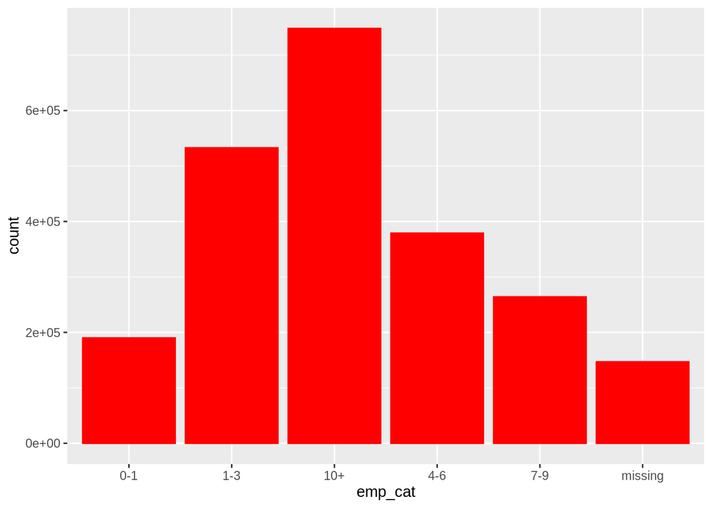

```r
# View emp_length
# Will keep missing values. Categorical variable. Will make six bins <1, 1-3, 3-6, 6-9, 10+, missing
raw.data$emp_cat <- rep(NA, length(raw.data$emp_length))
raw.data$emp_cat[which(raw.data$emp_length == "< 1 year")] <- "0-1"
raw.data$emp_cat[which(raw.data$emp_length == "1 year" | raw.data$emp_length=="2 years" | raw.data$emp_length=="3 years")] <- "1-3"
raw.data$emp_cat[which(raw.data$emp_length == "4 years" | raw.data$emp_length=="5 years" | raw.data$emp_length=="6 years")] <- "4-6"
raw.data$emp_cat[which(raw.data$emp_length == "7 years" | raw.data$emp_length=="8 years" | raw.data$emp_length=="9 years")] <- "7-9"
raw.data$emp_cat[which(raw.data$emp_length == "10+ years")] <- "10+"
raw.data$emp_cat[which(raw.data$emp_length == "n/a")] <- "missing"
raw.data$emp_cat <- as.factor(raw.data$emp_cat)
ggplot(raw.data, aes(x = emp_cat)) + geom_bar(color="red",fill="red")
```

Histogram of factorial variable emp_cat after using coarse classification to handle missing values

```r
str(raw.data)
```

```
## Classes 'data.table' and 'data.frame':   2260668 obs. of  20 variables:
##  $ loan_status   : chr  "Current" "Current" "Current" "Current" ...
##  $ grade         : chr  "C" "D" "D" "D" ...
##  $ sub_grade     : chr  "C1" "D2" "D1" "D2" ...
##  $ open_acc      : int  9 13 8 10 12 18 1 19 8 38 ...
##  $ pub_rec       : int  1 1 0 0 0 0 0 0 0 0 ...
##  $ dti           : num  18.2 26.5 10.5 16.7 26.4 ...
##  $ delinq_2yrs   : int  0 0 0 0 0 0 0 0 0 1 ...
##  $ inq_last_6mths: int  1 0 0 0 0 3 1 0 1 1 ...
##  $ emp_length    : chr  "10+ years" "10+ years" "6 years" "10+ years" ...
##  $ annual_inc    : num  55000 90000 59280 92000 57250 ...
##  $ home_ownership: chr  "RENT" "MORTGAGE" "MORTGAGE" "MORTGAGE" ...
##  $ purpose       : chr  "debt_consolidation" "debt_consolidation" "debt_consolidation" "debt_consolidation" ...
##  $ addr_state    : chr  "NY" "LA" "MI" "WA" ...
##  $ loan_amnt     : int  2500 30000 5000 4000 30000 5550 2000 6000 5000 6000 ...
##  $ int_rate      : num  13.6 18.9 18 18.9 16.1 ...
##  $ installment   : num  84.9 777.2 180.7 146.5 731.8 ...
##  $ issue_d       : chr  "Dec-2018" "Dec-2018" "Dec-2018" "Dec-2018" ...
##  $ revol_bal     : int  4341 12315 4599 5468 829 53854 0 38476 8018 65950 ...
##  $ revol_util    : num  10.3 24.2 19.1 78.1 3.6 48.1 NA 69.3 35.2 49.8 ...
##  $ emp_cat       : Factor w/ 6 levels "0-1","1-3","10+",..: 3 3 4 3 3 3 4 3 3 1 ...
##  - attr(*, ".internal.selfref")=<externalptr>
```

# (Data Cleaning) Preparing Data for Analysis

- [Factors](https://www.statmethods.net/input/datatypes.html)

```r
#int_rate variable
raw.data$int_rate <- as.numeric(sub("%","",raw.data$int_rate)) #Remove % sign and convert to numeric
class(raw.data$int_rate) # verify numeric
```

```
## [1] "numeric"
```

```r
raw.data$int_rate <- raw.data$int_rate / 100
is.numeric(raw.data$int_rate) # TRUE
```

```
## [1] TRUE
```

```r
anyNA(raw.data$int_rate) # FALSE (No missing values)
```

```
## [1] FALSE
```

```r
#revol_util variable
raw.data$revol_util <- as.numeric(sub("%","",raw.data$revol_util)) #Remove % sign; convert to numeric
class(raw.data$revol_util) # verify is numeric
```

```
## [1] "numeric"
```

```r
raw.data$revol_util <- raw.data$revol_util / 100
is.numeric(raw.data$revol_util) # TRUE
```

```
## [1] TRUE
```

```r
anyNA(raw.data$revol_util) # TRUE (There are missing values)
```

```
## [1] TRUE
```

```r
index.NA <- which(is.na(raw.data$revol_util))
median(raw.data$revol_util, na.rm = TRUE) #median value
```

```
## [1] 0.503
```

```r
raw.data$revol_util[index.NA] <- median(raw.data$revol_util, na.rm = TRUE) #Replace missing by median 0.503
anyNA(raw.data$revol_util) # FALSE (No missing values)
```

```
## [1] FALSE
```

```r
#revol_bal variable
class(raw.data$revol_bal) #should be numeric
```

```
## [1] "integer"
```

```r
raw.data$revol_bal <- as.character(raw.data$revol_bal) #Converting into character
raw.data$revol_bal <- as.numeric(raw.data$revol_bal) # Converting into numeric
anyNA(raw.data$revol_bal) #No missing values
```

```
## [1] FALSE
```

```r
#installment variable
class(raw.data$installment) #It is factor, should be numeric
```

```
## [1] "numeric"
```

```r
raw.data$installment <- as.character(raw.data$installment) #Converting into character
raw.data$installment <- as.numeric(raw.data$installment) #Converting into numeric
is.numeric(raw.data$installment) # TRUE
```

```
## [1] TRUE
```

```r
anyNA(raw.data$installment) #No missing values
```

```
## [1] FALSE
```

```r
#loan_amnt
class(raw.data$loan_amnt) #It is factor, should be numeric
```

```
## [1] "integer"
```

```r
raw.data$loan_amnt <- as.character(raw.data$loan_amnt) #Converting into character
raw.data$loan_amnt <- as.numeric(raw.data$loan_amnt) #Converting into numeric
is.numeric(raw.data$loan_amnt) # TRUE
```

```
## [1] TRUE
```

```r
anyNA(raw.data$loan_amnt) #No missing values
```

```
## [1] FALSE
```

```r
#annual_inc
class(raw.data$annual_inc) #It is factor, should be numeric
```

```
## [1] "numeric"
```

```r
raw.data$annual_inc <- as.character(raw.data$annual_inc) #Converting into character
raw.data$annual_inc <- as.numeric(raw.data$annual_inc) #Converting into numeric
is.numeric(raw.data$annual_inc) # TRUE
```

```
## [1] TRUE
```

```r
anyNA(raw.data$annual_inc) #4 missing values
```

```
## [1] TRUE
```

```r
index.NA <- which(is.na(raw.data$annual_inc))
raw.data$annual_inc[index.NA] <- median(raw.data$annual_inc, na.rm = TRUE)
anyNA(raw.data$annual_inc) #No missing values
```

```
## [1] FALSE
```

```r
#dti
class(raw.data$dti) #It is factor, should be numeric
```

```
## [1] "numeric"
```

```r
raw.data$dti <- as.character(raw.data$dti) #Converting into character
raw.data$dti <- as.numeric(raw.data$dti) #Converting into numeric
is.numeric(raw.data$dti) # TRUE
```

```
## [1] TRUE
```

```r
anyNA(raw.data$dti) #There are missing values
```

```
## [1] TRUE
```

```r
index.NA <- which(is.na(raw.data$dti))
median(raw.data$dti, na.rm = TRUE) #median value
```

```
## [1] 17.84
```

```r
raw.data$dti[index.NA] <- median(raw.data$dti, na.rm = TRUE) #Replace missing by median 17.84
anyNA(raw.data$dti) # FALSE (No missing values)
```

```
## [1] FALSE
```

```r
#open_acc
class(raw.data$open_acc) #It is factor, should be numeric
```

```
## [1] "integer"
```

```r
raw.data$open_acc <- as.character(raw.data$open_acc) #Converting into character
raw.data$open_acc <- as.numeric(raw.data$open_acc) #Converting into numeric
is.numeric(raw.data$open_acc) # TRUE
```

```
## [1] TRUE
```

```r
anyNA(raw.data$open_acc) #missing values
```

```
## [1] TRUE
```

```r
index.NA <- which(is.na(raw.data$open_acc))
median(raw.data$open_acc, na.rm = TRUE) #median value
```

```
## [1] 11
```

```r
raw.data$open_acc[index.NA] <- median(raw.data$open_acc, na.rm = TRUE) #Replace missing by median 11
anyNA(raw.data$open_acc) # FALSE (No missing values)
```

```
## [1] FALSE
```

```r
#pub_rec
class(raw.data$pub_rec) #It is factor, should be numeric
```

```
## [1] "integer"
```

```r
raw.data$pub_rec <- as.character(raw.data$pub_rec) #Converting into character
raw.data$pub_rec <- as.numeric(raw.data$pub_rec) #Converting into numeric
is.numeric(raw.data$pub_rec) # TRUE
```

```
## [1] TRUE
```

```r
anyNA(raw.data$pub_rec) #missing values
```

```
## [1] TRUE
```

```r
index.NA <- which(is.na(raw.data$pub_rec))
median(raw.data$pub_rec, na.rm = TRUE) #median value
```

```
## [1] 0
```

```r
raw.data$pub_rec[index.NA] <- median(raw.data$pub_rec, na.rm = TRUE) #Replace missing by median 0
anyNA(raw.data$pub_rec) # FALSE (No missing values)
```

```
## [1] FALSE
```

```r
#delinq_2yrs
class(raw.data$delinq_2yrs) #It is factor, should be numeric
```

```
## [1] "integer"
```

```r
raw.data$delinq_2yrs <- as.character(raw.data$delinq_2yrs) #Converting into character
raw.data$delinq_2yrs <- as.numeric(raw.data$delinq_2yrs) #Converting into numeric
is.numeric(raw.data$delinq_2yrs) # TRUE
```

```
## [1] TRUE
```

```r
anyNA(raw.data$delinq_2yrs) #missing values
```

```
## [1] TRUE
```

```r
index.NA <- which(is.na(raw.data$delinq_2yrs))
median(raw.data$delinq_2yrs, na.rm = TRUE) #median value
```

```
## [1] 0
```

```r
raw.data$delinq_2yrs[index.NA] <- median(raw.data$delinq_2yrs, na.rm = TRUE) #Replace missing by median 0
anyNA(raw.data$delinq_2yrs) # FALSE (No missing values)
```

```
## [1] FALSE
```

```r
#inq_last_6mths
class(raw.data$inq_last_6mths) #It is factor, should be numeric
```

```
## [1] "integer"
```

```r
raw.data$inq_last_6mths <- as.character(raw.data$inq_last_6mths) #Converting into character
raw.data$inq_last_6mths <- as.numeric(raw.data$inq_last_6mths) #Converting into numeric
is.numeric(raw.data$inq_last_6mths) # TRUE
```

```
## [1] TRUE
```

```r
anyNA(raw.data$inq_last_6mths) #missing values
```

```
## [1] TRUE
```

```r
index.NA <- which(is.na(raw.data$inq_last_6mths))
median(raw.data$inq_last_6mths, na.rm = TRUE) #median value
```

```
## [1] 0
```

```r
raw.data$inq_last_6mths[index.NA] <- median(raw.data$inq_last_6mths, na.rm = TRUE) #Replace missing by median 0
anyNA(raw.data$inq_last_6mths) # FALSE (No missing values)
```

```
## [1] FALSE
```

```r
str(raw.data)
```

```
## Classes 'data.table' and 'data.frame':   2260668 obs. of  20 variables:
##  $ loan_status   : chr  "Current" "Current" "Current" "Current" ...
##  $ grade         : chr  "C" "D" "D" "D" ...
##  $ sub_grade     : chr  "C1" "D2" "D1" "D2" ...
##  $ open_acc      : num  9 13 8 10 12 18 1 19 8 38 ...
##  $ pub_rec       : num  1 1 0 0 0 0 0 0 0 0 ...
##  $ dti           : num  18.2 26.5 10.5 16.7 26.4 ...
##  $ delinq_2yrs   : num  0 0 0 0 0 0 0 0 0 1 ...
##  $ inq_last_6mths: num  1 0 0 0 0 3 1 0 1 1 ...
##  $ emp_length    : chr  "10+ years" "10+ years" "6 years" "10+ years" ...
##  $ annual_inc    : num  55000 90000 59280 92000 57250 ...
##  $ home_ownership: chr  "RENT" "MORTGAGE" "MORTGAGE" "MORTGAGE" ...
##  $ purpose       : chr  "debt_consolidation" "debt_consolidation" "debt_consolidation" "debt_consolidation" ...
##  $ addr_state    : chr  "NY" "LA" "MI" "WA" ...
##  $ loan_amnt     : num  2500 30000 5000 4000 30000 5550 2000 6000 5000 6000 ...
##  $ int_rate      : num  0.136 0.189 0.18 0.189 0.161 ...
##  $ installment   : num  84.9 777.2 180.7 146.5 731.8 ...
##  $ issue_d       : chr  "Dec-2018" "Dec-2018" "Dec-2018" "Dec-2018" ...
##  $ revol_bal     : num  4341 12315 4599 5468 829 ...
##  $ revol_util    : num  0.103 0.242 0.191 0.781 0.036 0.481 0.503 0.693 0.352 0.498 ...
##  $ emp_cat       : Factor w/ 6 levels "0-1","1-3","10+",..: 3 3 4 3 3 3 4 3 3 1 ...
##  - attr(*, ".internal.selfref")=<externalptr>
```

### Loan Status

The *dependent variable* in our model is *loan_status* (i.e., we are trying to predict if a loan will be paid based on the attributes above). In the raw dataset it has 9 different values. However, in our model we will use two values Fully Paid which means that the loan was paid, and Charged Off which means that there is no longer a reasonable expectation of further payments. We will encode this variable and 1 will represent Fully Paid, while 0 will represent Charged Off. We do the encoding in the code below:

```r
#laon_status
class(raw.data$loan_status) #It is factor
```

```
## [1] "character"
```

```r
raw.data$loan_status <- as.character(raw.data$loan_status)
is.character(raw.data$loan_status)
```

```
## [1] TRUE
```

```r
#Taking only rows where laon_status is fully paid or charged off
arg <- raw.data$loan_status=="Fully Paid" | raw.data$loan_status=="Charged Off"
raw.data <- subset(raw.data, arg==TRUE) #Number of observations reduced

#Encoding loan_status
#0 - Charged Off,
#1 - Fully paid
raw.data$loan_status <- ifelse(raw.data$loan_status=="Fully Paid",1,0)
raw.data$loan_status <- as.integer(raw.data$loan_status) #Converting to integer

is.integer(raw.data$loan_status)
```

```
## [1] TRUE
```

```r
anyNA(raw.data$loan_status)
```

```
## [1] FALSE
```

```r
nrow(raw.data)
```

```
## [1] 1303607
```

```r
ncol(raw.data)
```

```
## [1] 20
```

# Exploratory Data Analysis (EDA)

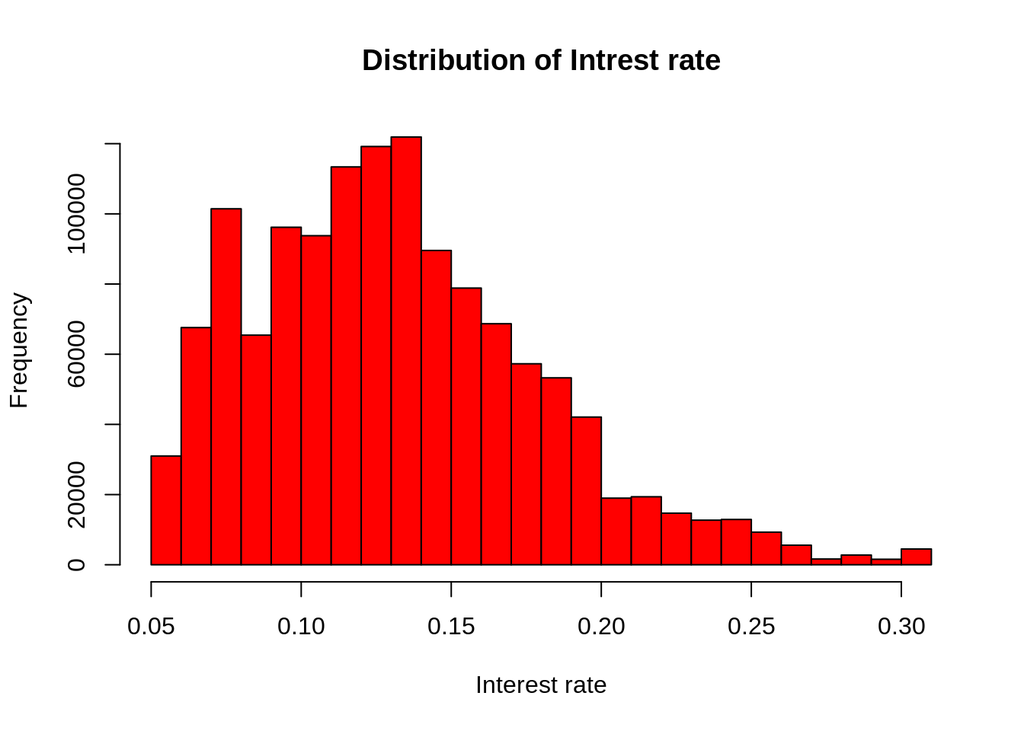

```r
# Distribution of Interest rate
hist(raw.data$int_rate, col = "red", main = "Distribution of Intrest rate", xlab = "Interest rate")
```

```r
summary(raw.data$int_rate)
```

```
##    Min. 1st Qu.  Median    Mean 3rd Qu.    Max.
##  0.0531  0.0975  0.1274  0.1326  0.1599  0.3099
```

```r
#Turning loan_status to factor
raw.data$loan_status <- factor(raw.data$loan_status)
```

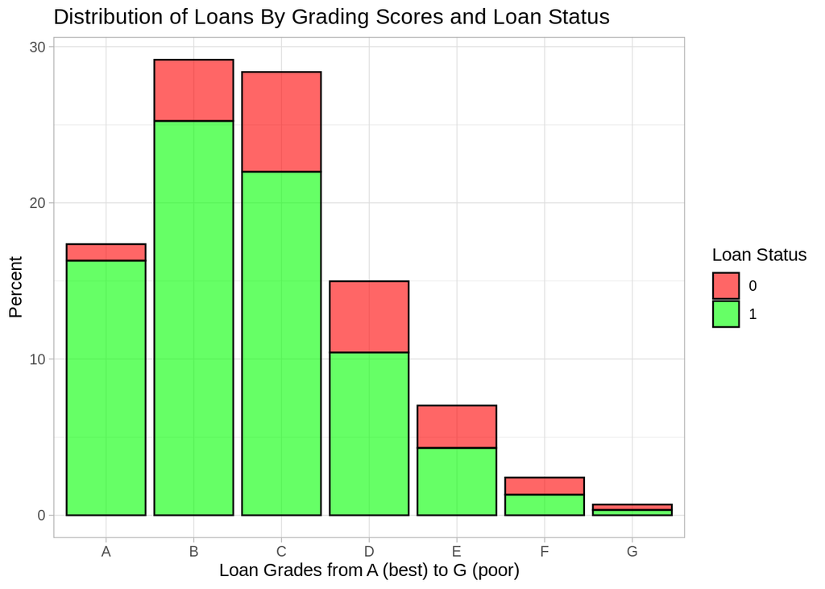

```r
#Distribution of grade scores
#Histogram of grade score colored by loan_status in percentage
plot1 <- ggplot(raw.data,aes(x=grade, y=((..count..)/sum(..count..))*100))
plot1 <- plot1 + geom_histogram(aes(fill=loan_status), color="black", stat = "count", alpha=0.6)
plot1 <- plot1 + theme_light()
plot1 <- plot1 + scale_fill_manual("Loan Status",values = c("red", "green")) +
  labs(y="Percent", x="Loan Grades from A (best) to G (poor)")
plot1 <- plot1 + ggtitle("Distribution of Loans By Grading Scores and Loan Status")
plot1
```

```r
#Making Contingency Table to check percentage of grading score in relation with unpaid loans
CrossTable(raw.data$grade, raw.data$loan_status,prop.r = TRUE, prop.c = FALSE, prop.t = FALSE,
           prop.chisq = FALSE )
```

```
##
##
##    Cell Contents
## |-------------------------|
## |                       N |
## |           N / Row Total |
## |-------------------------|
##
##
## Total Observations in Table:  1303607
##
##
##                | raw.data$loan_status
## raw.data$grade |         0 |         1 | Row Total |
## ---------------|-----------|-----------|-----------|
##              A |     13766 |    212477 |    226243 |
##                |     0.061 |     0.939 |     0.174 |
## ---------------|-----------|-----------|-----------|
##              B |     51077 |    329075 |    380152 |
##                |     0.134 |     0.866 |     0.292 |
## ---------------|-----------|-----------|-----------|
##              C |     83262 |    286666 |    369928 |
##                |     0.225 |     0.775 |     0.284 |
## ---------------|-----------|-----------|-----------|
##              D |     59441 |    135839 |    195280 |
##                |     0.304 |     0.696 |     0.150 |
## ---------------|-----------|-----------|-----------|
##              E |     35364 |     56206 |     91570 |
##                |     0.386 |     0.614 |     0.070 |
## ---------------|-----------|-----------|-----------|
##              F |     14263 |     17220 |     31483 |
##                |     0.453 |     0.547 |     0.024 |
## ---------------|-----------|-----------|-----------|
##              G |      4482 |      4469 |      8951 |
##                |     0.501 |     0.499 |     0.007 |
## ---------------|-----------|-----------|-----------|
##   Column Total |    261655 |   1041952 |   1303607 |
## ---------------|-----------|-----------|-----------|
##
##
```

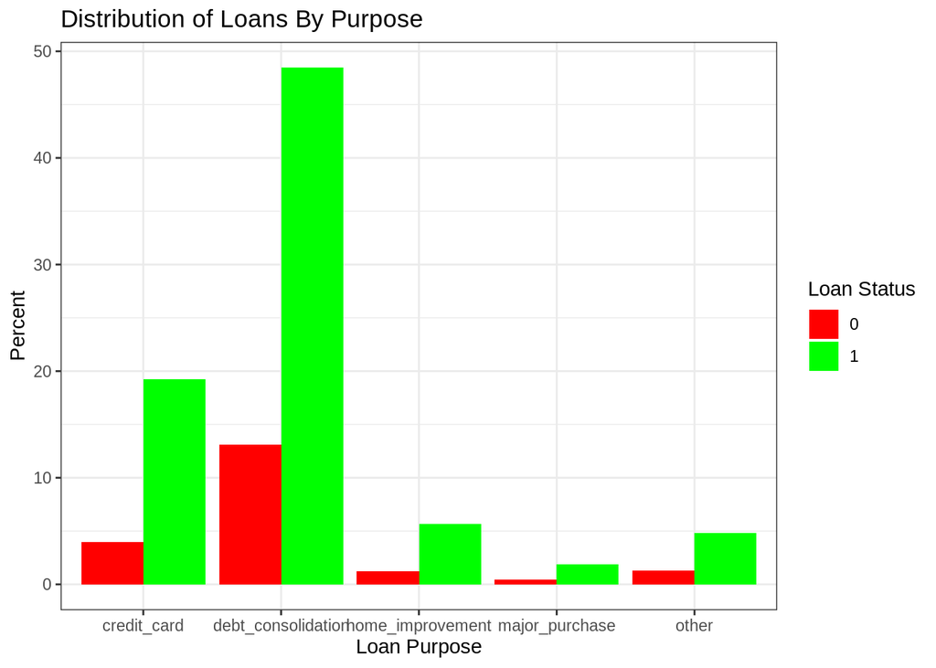

```r
#Taking the highest loan purposes
arg <- raw.data$purpose == "credit_card" | raw.data$purpose == "debt_consolidation" |
        raw.data$purpose == "home_improvement" | raw.data$purpose == "major_purchase" |
        raw.data$purpose == "other"
j <- subset(raw.data, arg==TRUE)

#Making distribution of loans by purpose
plot2 <- ggplot(j,aes(x=purpose, y=((..count..)/sum(..count..))*100))
plot2 <- plot2 + geom_bar(aes(fill=loan_status), position = "dodge", stat = "count")
plot2 <- plot2 + theme_bw()
plot2 <- plot2 + scale_fill_manual("Loan Status",values = c("red", "green")) +
  labs(y="Percent", x="Loan Purpose")
plot2 <- plot2 + ggtitle("Distribution of Loans By Purpose")
plot2
```

```r
#Making Contingency Table to check percentage of grading score in relation with unpaid loans
CrossTable(raw.data$purpose, raw.data$loan_status,prop.r = TRUE, prop.c = FALSE, prop.t = FALSE,
           prop.chisq = FALSE )
```

```
##
##
##    Cell Contents
## |-------------------------|
## |                       N |
## |           N / Row Total |
## |-------------------------|
##
##
## Total Observations in Table:  1303607
##
##
##                    | raw.data$loan_status
##   raw.data$purpose |         0 |         1 | Row Total |
## -------------------|-----------|-----------|-----------|
##                car |      2067 |     12053 |     14120 |
##                    |     0.146 |     0.854 |     0.011 |
## -------------------|-----------|-----------|-----------|
##        credit_card |     48646 |    237058 |    285704 |
##                    |     0.170 |     0.830 |     0.219 |
## -------------------|-----------|-----------|-----------|
## debt_consolidation |    161039 |    596552 |    757591 |
##                    |     0.213 |     0.787 |     0.581 |
## -------------------|-----------|-----------|-----------|
##        educational |        56 |       270 |       326 |
##                    |     0.172 |     0.828 |     0.000 |
## -------------------|-----------|-----------|-----------|
##   home_improvement |     15085 |     69410 |     84495 |
##                    |     0.179 |     0.821 |     0.065 |
## -------------------|-----------|-----------|-----------|
##              house |      1513 |      5454 |      6967 |
##                    |     0.217 |     0.783 |     0.005 |
## -------------------|-----------|-----------|-----------|
##     major_purchase |      5304 |     23024 |     28328 |
##                    |     0.187 |     0.813 |     0.022 |
## -------------------|-----------|-----------|-----------|
##            medical |      3291 |     11732 |     15023 |
##                    |     0.219 |     0.781 |     0.012 |
## -------------------|-----------|-----------|-----------|
##             moving |      2150 |      7022 |      9172 |
##                    |     0.234 |     0.766 |     0.007 |
## -------------------|-----------|-----------|-----------|
##              other |     15864 |     59070 |     74934 |
##                    |     0.212 |     0.788 |     0.057 |
## -------------------|-----------|-----------|-----------|
##   renewable_energy |       216 |       695 |       911 |
##                    |     0.237 |     0.763 |     0.001 |
## -------------------|-----------|-----------|-----------|
##     small_business |      4465 |     10545 |     15010 |
##                    |     0.297 |     0.703 |     0.012 |
## -------------------|-----------|-----------|-----------|
##           vacation |      1680 |      7052 |      8732 |
##                    |     0.192 |     0.808 |     0.007 |
## -------------------|-----------|-----------|-----------|
##            wedding |       279 |      2015 |      2294 |
##                    |     0.122 |     0.878 |     0.002 |
## -------------------|-----------|-----------|-----------|
##       Column Total |    261655 |   1041952 |   1303607 |
## -------------------|-----------|-----------|-----------|
##
##
```

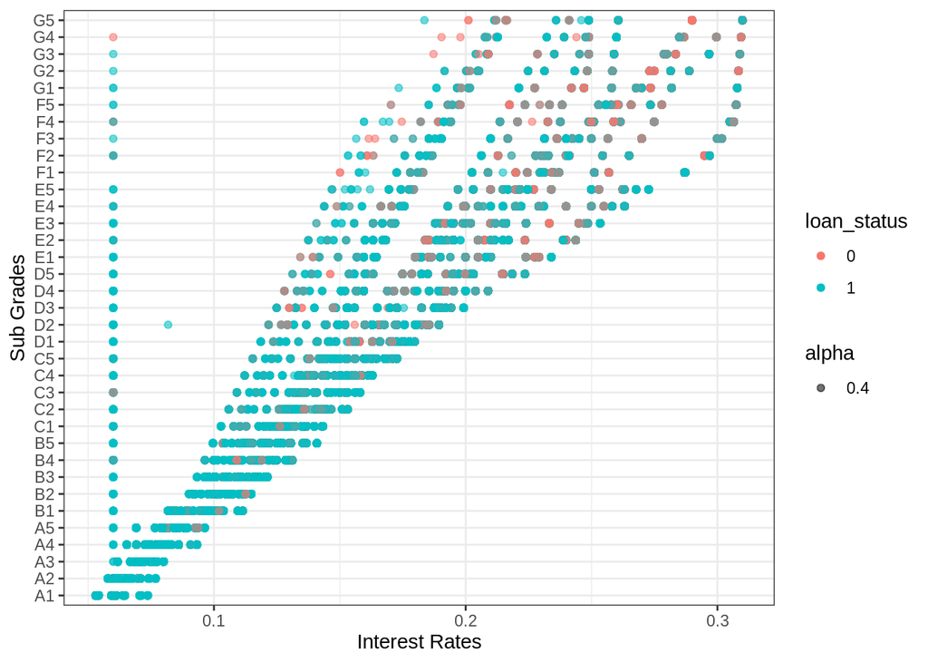

```r
#Making scatter diagram to control relation between interest rates and loans grades
plot3 <- ggplot(raw.data, aes(x=int_rate, y=sub_grade)) + geom_point(aes(color=loan_status, alpha=0.4))
plot3 <- plot3 + theme_bw() + scale_fill_manual("Loan Status", values = c("red", "green")) +
  labs(y="Sub Grades", x="Interest Rates")
plot3
```

In the scatter plot we see a column of outliers at 0.06. We can remove.

```r
#Deleting detected outliers
arg <- raw.data$int_rate==0.06 & raw.data$sub_grade=="G1"
raw.data <- subset(raw.data, arg==FALSE)

arg <- raw.data$int_rate==0.06 & raw.data$sub_grade=="G2"
raw.data <- subset(raw.data, arg==FALSE)

arg <- raw.data$int_rate==0.06 & raw.data$sub_grade=="G3"
raw.data <- subset(raw.data, arg==FALSE)

arg <- raw.data$int_rate==0.06 & raw.data$sub_grade=="G4"
raw.data <- subset(raw.data, arg==FALSE)

arg <- raw.data$int_rate==0.06 & raw.data$sub_grade=="F5"
raw.data <- subset(raw.data, arg==FALSE)

arg <- raw.data$int_rate==0.06 & raw.data$sub_grade=="F4"
raw.data <- subset(raw.data, arg==FALSE)

arg <- raw.data$int_rate==0.06 & raw.data$sub_grade=="F3"
raw.data <- subset(raw.data, arg==FALSE)

arg <- raw.data$int_rate==0.06 & raw.data$sub_grade=="F2"
raw.data <- subset(raw.data, arg==FALSE)

arg <- raw.data$int_rate==0.06 & raw.data$sub_grade=="E5"
raw.data <- subset(raw.data, arg==FALSE)

arg <- raw.data$int_rate==0.06 & raw.data$sub_grade=="E4"
raw.data <- subset(raw.data, arg==FALSE)

arg <- raw.data$int_rate==0.06 & raw.data$sub_grade=="E3"
raw.data <- subset(raw.data, arg==FALSE)

arg <- raw.data$int_rate==0.06 & raw.data$sub_grade=="E2"
raw.data <- subset(raw.data, arg==FALSE)

arg <- raw.data$int_rate==0.06 & raw.data$sub_grade=="E1"
raw.data <- subset(raw.data, arg==FALSE)

arg <- raw.data$int_rate==0.06 & raw.data$sub_grade=="D5"
raw.data <- subset(raw.data, arg==FALSE)

arg <- raw.data$int_rate==0.06 & raw.data$sub_grade=="D4"
raw.data <- subset(raw.data, arg==FALSE)

arg <- raw.data$int_rate==0.06 & raw.data$sub_grade=="D3"
raw.data <- subset(raw.data, arg==FALSE)

arg <- raw.data$int_rate==0.06 & raw.data$sub_grade=="D2"
raw.data <- subset(raw.data, arg==FALSE)

arg <- raw.data$int_rate==0.06 & raw.data$sub_grade=="D1"
raw.data <- subset(raw.data, arg==FALSE)

arg <- raw.data$int_rate==0.06 & raw.data$sub_grade=="C5"
raw.data <- subset(raw.data, arg==FALSE)

arg <- raw.data$int_rate==0.06 & raw.data$sub_grade=="C4"
raw.data <- subset(raw.data, arg==FALSE)

arg <- raw.data$int_rate==0.06 & raw.data$sub_grade=="C3"
raw.data <- subset(raw.data, arg==FALSE)

arg <- raw.data$int_rate==0.06 & raw.data$sub_grade=="C2"
raw.data <- subset(raw.data, arg==FALSE)

arg <- raw.data$int_rate==0.06 & raw.data$sub_grade=="C1"
raw.data <- subset(raw.data, arg==FALSE)

arg <- raw.data$int_rate==0.06 & raw.data$sub_grade=="B5"
raw.data <- subset(raw.data, arg==FALSE)

arg <- raw.data$int_rate==0.06 & raw.data$sub_grade=="B4"
raw.data <- subset(raw.data, arg==FALSE)

arg <- raw.data$int_rate==0.06 & raw.data$sub_grade=="B3"
raw.data <- subset(raw.data, arg==FALSE)

arg <- raw.data$int_rate==0.06 & raw.data$sub_grade=="B2"
raw.data <- subset(raw.data, arg==FALSE)

arg <- raw.data$int_rate==0.06 & raw.data$sub_grade=="B1"
raw.data <- subset(raw.data, arg==FALSE)
```

Plot again without outliers

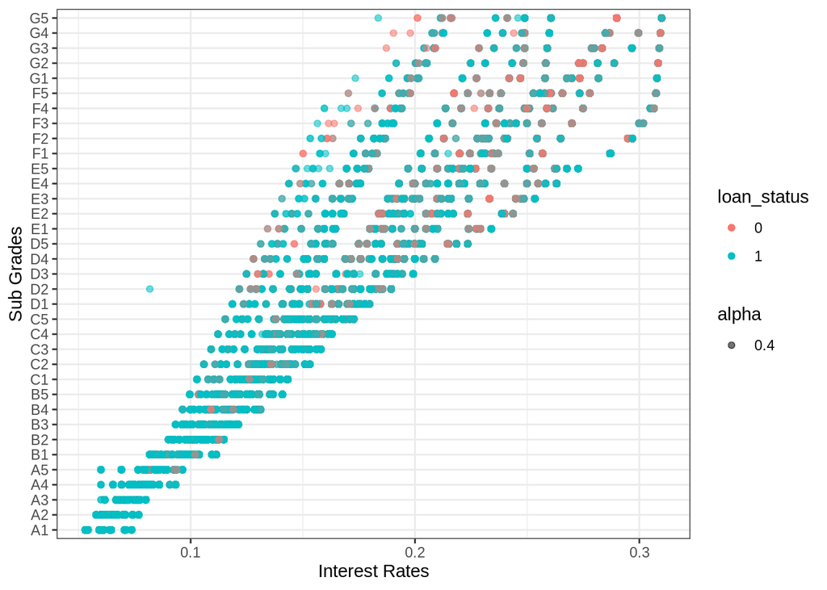

```r
#Making 2nd scatter diagram between interest rates and loans grades
plot3 <- ggplot(raw.data, aes(x=int_rate, y=sub_grade)) + geom_point(aes(color=loan_status, alpha=0.4))
plot3 <- plot3 + theme_bw() + scale_fill_manual("Loan Status", values = c("red", "green")) +
  labs(y="Sub Grades", x="Interest Rates")
plot3
```

```r
#5-number summary statistics for annual income
summary(raw.data$annual_inc) #There are potential outliers
```

```
##     Min.  1st Qu.   Median     Mean  3rd Qu.     Max.
##        0    45840    65000    76161    90000 10999200
```

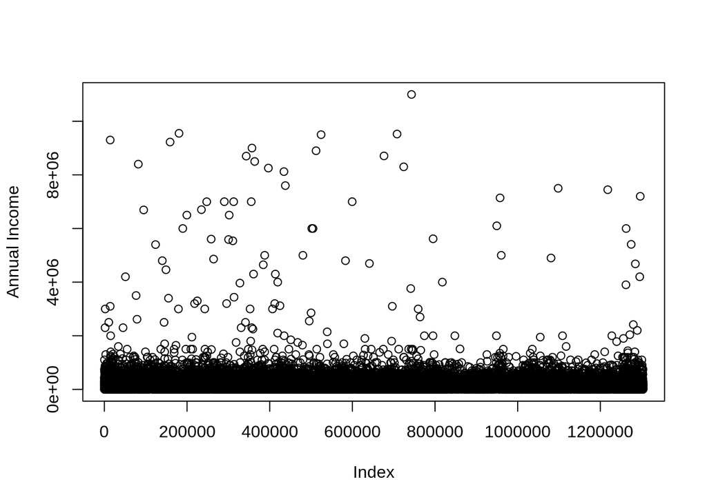

```r
#Plotting scatter diagram to detect outliers
plot(raw.data$annual_inc, ylab = "Annual Income")
```

```r
#Removing outliers
index.outliers <- which(raw.data$annual_inc > 1000000) #91 outliers detected
raw.data <- raw.data[-index.outliers,] #Outliers deleted
```

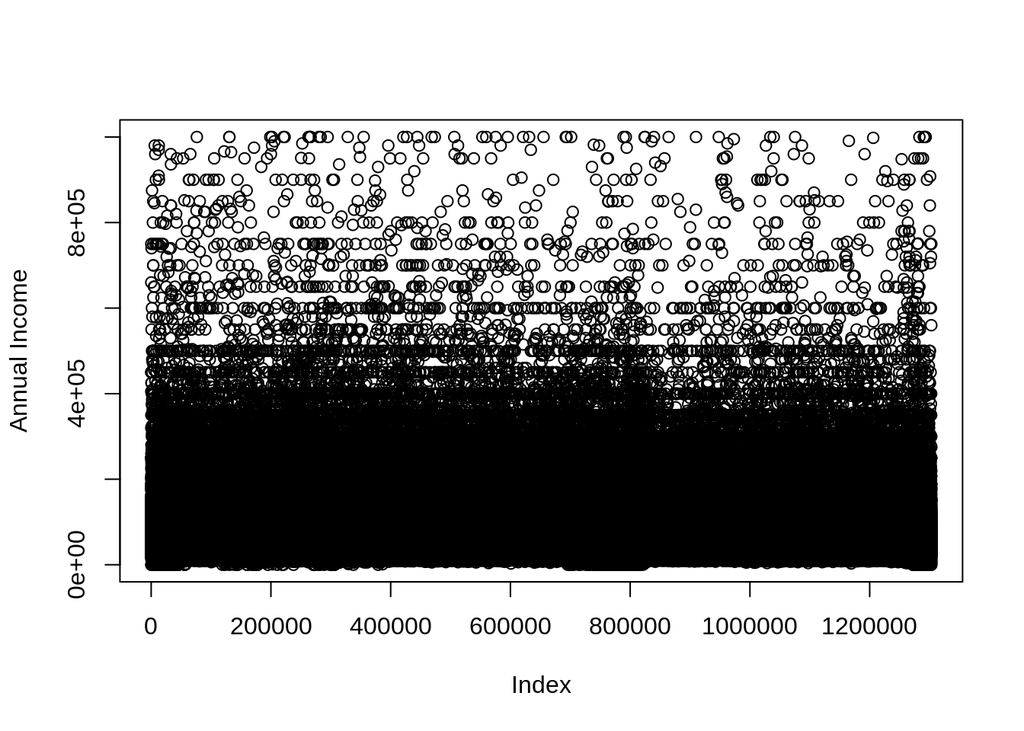

```r
#Plotting scatter diagram withouy outliers
plot(raw.data$annual_inc, ylab = "Annual Income")
```

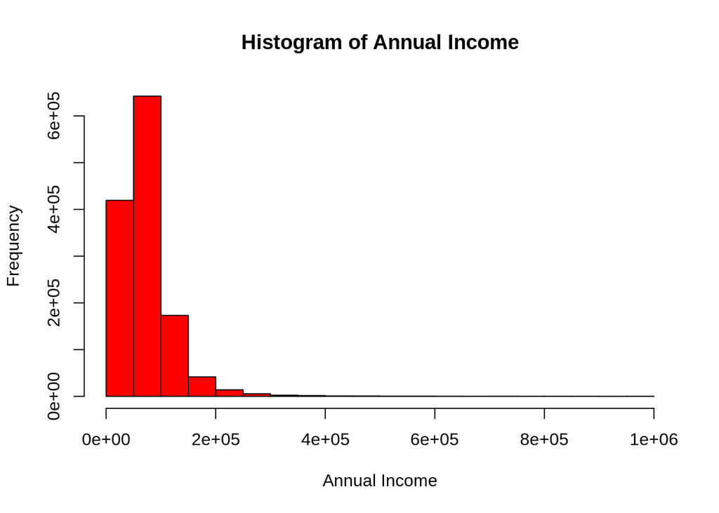

```r
#Histogram for Annual Income
hist(raw.data$annual_inc, col="red", xlab = "Annual Income", main = "Histogram of Annual Income")
```

Continue to remove outliers….

```r
#Removing outliers for dti
summary(raw.data$dti)
```

```
##    Min. 1st Qu.  Median    Mean 3rd Qu.    Max.
##   -1.00   11.80   17.61   18.26   24.04  999.00
```